# Homework 1

Bingying Liu (bl199)

January 22, 2020

### Question 1

1. $p(y=head)= \sum_{\theta \in {fair,fake}} p(y|\theta)*p(\theta) = \frac{2}{3}*0.5 + \frac{1}{3}*1 = \frac{2}{3}$  
   Therefore, the probability that it lands on heads is $\frac{2}{3}$.

$\begin{align*} p(\theta=fake|y=head) &= \frac{p(\theta,y)}{p(y)} \\ &= \frac{p(y|\theta) * p(\theta)}{p(y)}\\ &= \frac{1 * \frac{1}{3}}{\frac{2}{3}}\\ &= \frac{1}{2} \end{align*}$  
The probability that it’s the fake coin is 50%.

### Question 2

1. Since $p(x|y,z) = \frac{p(x,y,z)}{p(y,z)} = \frac{c * f(x,z) * g(y,z) * p(z)}{p(y,z)} = \frac{c * g(y,z) * p(z)}{p(y,z)} * f(x,z)$  
   Assuming c is a constant and since $p(x|y,z)$ consists of multiplier $\frac{c * g(y,z) * p(z)}{p(y,z)}$ and function $f(x,z)$, we can say that $p(x|y,z)$ is a function of x and z.
2. Same reason as above: since $p(y|x,z) = \frac{p(x,y,z)}{p(x,z)} = \frac{c * f(x,z) * g(y,z) * p(z)}{p(x,z)} = \frac{c * f(x,z) * p(z)}{p(x,z)} * g(y,z)$  
   Assuming c is a constant and since $p(y|x,z)$ consists of multiplier $\frac{c * f(x,z) * p(z)}{p(x,z)}$ and function $g(y,z)$, we can say that $p(y|x,z)$ is a function of y and z.
3. Since we know $p(x,y|z) = p(x|y,z) * p(y|z)$, to prove $p(x,y|z) = p(x|z) * p(y|z)$, we only need to show that $p(x|y,z) = p(x|z)$.

$\begin{align*} p(x|z) &= \frac{p(x,z)}{p(z)} \\ &= \frac{\int p(x,y,z) dy}{\int p(x,y,z) dx dy} \\ &= \frac{c \int f(x,z) * g(y,z) * h(z) dy}{c \int f(x,z) * g(y,z) * h(z) dx dy} \text{assuming p(x,y,z) = c * f(x,z) * g(y,z) * h(z) and c is a constant}\\ &= \frac{h(z) * G(z) * f(x,z)}{H(z)} \text{we set $G(z)=\int g(y,z)dy$ and $H(z)=\int f(x,z) * g(y,z) * h(z) dx dy$, they're both functions of z} \end{align*}$

Since we can treat $\frac{h(z)G(z)}{H(z)}$ as a numerical value, we can say that $p(x|z) \propto f(x,z)$, which is the same as $p(x|y,z) \propto f(x,z)$ proved in a). Therefore, this equality is proved and we can say that X and Y are conditionally independent given Z.

### Question 3

Since the posterior distribution is $beta(a+y, b+n-y)$, we have the variance of posterior as:

$\begin{align*} V(\theta|y) &= \frac{(a+y)(b+n-y)}{(a+b+n)^2 * (a+b+n+1)} \\ &= \frac{a+y}{a+b+n} * \frac{b+n-y}{a+b+n} * \frac{1}{a+b+n+1} \\ &= E(\theta|y) * \frac{a+b+n-a-y}{a+b+n} * \frac{1}{a+b+n+1} \\ &= E(\theta|y) * (1 - E(\theta|y)) * \frac{1}{a+b+n+1}\\ &= \frac{E(\theta|y) * (1 - E(\theta|y))}{a+b+n+1} \end{align*}$

### Question 4: Hoff 3.1

- Joint distribution is the following:  
  $\begin{align*} p(Y_1=y_1, ..., Y_{100}=y_{100} |\theta) &= p(Y_1=y_1|\theta)*...*p(Y_{100}=y_{100}|\theta) \\ &= \prod_{i=1}^{n} \theta^{y_i} * (1-\theta)^{1-y_i}\\ &= \theta^{\sum_{i=1}^{n} y_i} * (1-\theta)^{n - \sum_{i=1}^{n} y_i} \\ &= \theta^{Y} * (1-\theta)^{n-Y} \end{align*}$  
  assuming $Y = \sum_{i=1}^{n} y_i$.
- Since $\sum Y_i$ are the number of individuals who support policy Z from 100 individuals (Bernoulli trials), it follows that $p(\sum Y_i = y |\theta)$ is a binomial distribution.  
  $\begin{align*} p(\sum Y_i = y |\theta) &= {n\choose y} \theta^y (1-\theta)^{n-y} \\ &= {100\choose y} \theta^y (1-\theta)^{100-y} \end{align*}$
2. Compute sampling distribution for each $\theta$ and make a plot of the probabilities as a function of $\theta$.

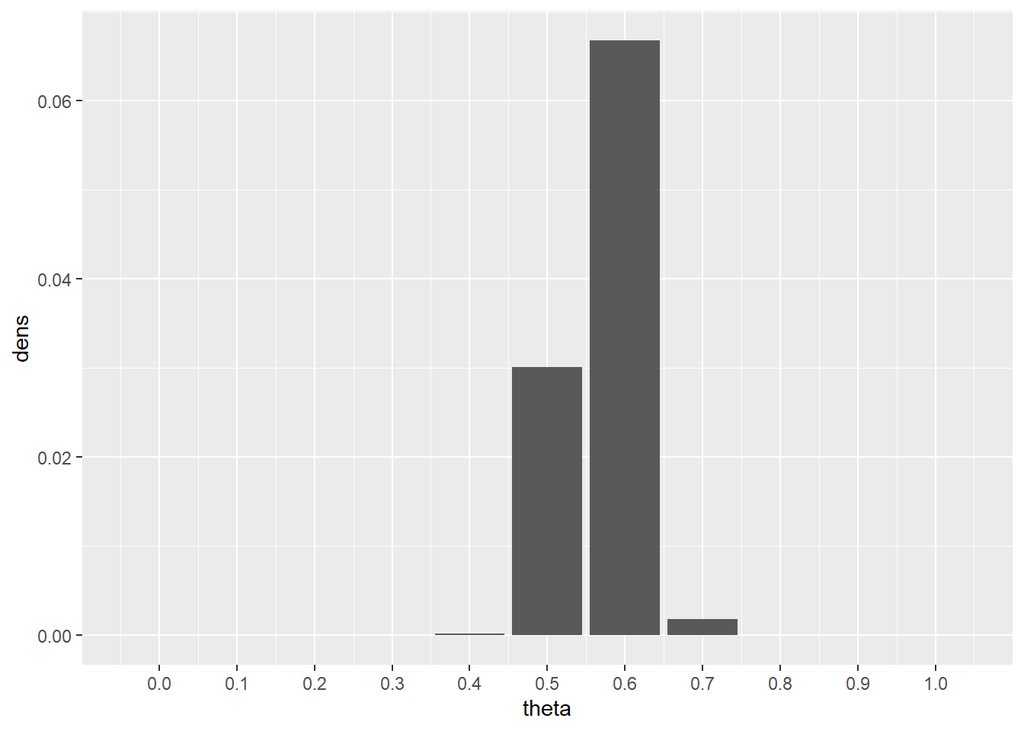

```r
Y = 57
N = 100
theta <- seq(from=0, to=1, by=0.1)
dens <-  choose(N,Y) * theta^Y*(1-theta)^(N-Y) # sum of Y as sufficient statistics is a binomial distribution
df <- data.frame(theta, dens)

ggplot(df, aes(x = theta, y = dens)) +
  geom_bar(stat = 'identity') +
  scale_x_continuous(breaks = theta)
```

3. Compute posterior distribution for each $\theta$ and make a plot of this as a function of $\theta$

$\begin{align} p(\theta \mid \sum Y_i = 57) &= \frac{p(\sum Y_i = 57 \mid \theta)p(\theta)}{p(\sum Y_i = 57)} \\ &= \frac{p(\sum Y_i = 57 \mid \theta)p(\theta)}{\sum_{\theta'} p(\sum Y_i = 57 \mid \theta') p(\theta')} \\ &= \frac{p(\sum Y_i = 57 \mid \theta)}{\sum_{\theta'} p(\sum Y_i = 57 \mid \theta')} \\ &\propto p(\sum Y_i = 57 \mid \theta) \end{align}$

The second to last step is derived because we have a uniform prior so $p(\theta) = p(\theta')$ and the last step is derived because we know that the denominator is a constant.

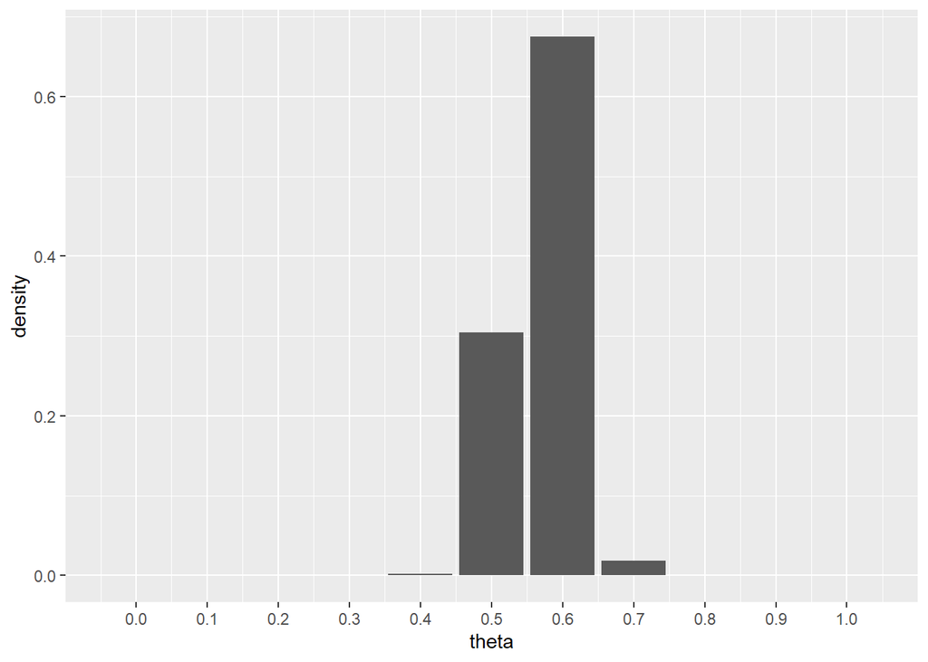

```r
prior <- dbeta(theta,1,1)
posterior <- prior * dens/sum(dens)
ggplot(df, aes(x = theta, y = posterior)) +
  geom_bar(stat = 'identity') +
  scale_x_continuous(breaks = theta)+
  ylab('density')
```

4. Plot the posterior density as a function of $theta$ using $p(\theta) \times P(\sum Y_i = 57 \mid \theta)$.

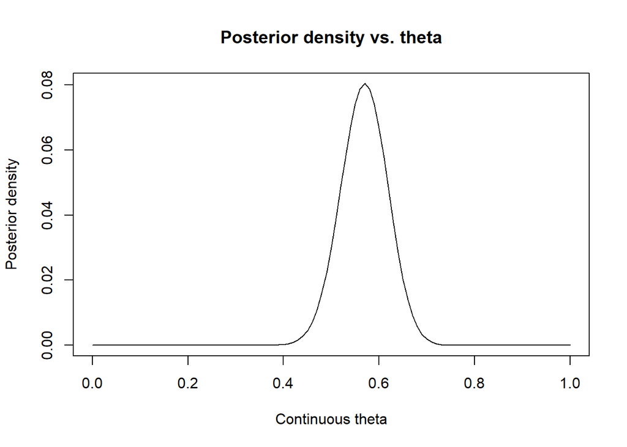

```r
theta.any <- seq(from=0, to=1, by=0.01)
posterior_wlcons <-  choose(N,Y) * theta.any^Y*(1-theta.any)^(N-Y)
plot(theta.any, type='l',posterior_wlcons, xlim=c(0,1),xlab = "Continuous theta", ylab = "Posterior density", main="Posterior density vs. theta")
```

5. Plot the posterior density of as a function of $theta$ using $\theta = beta(1+57, 1+100-57)$.

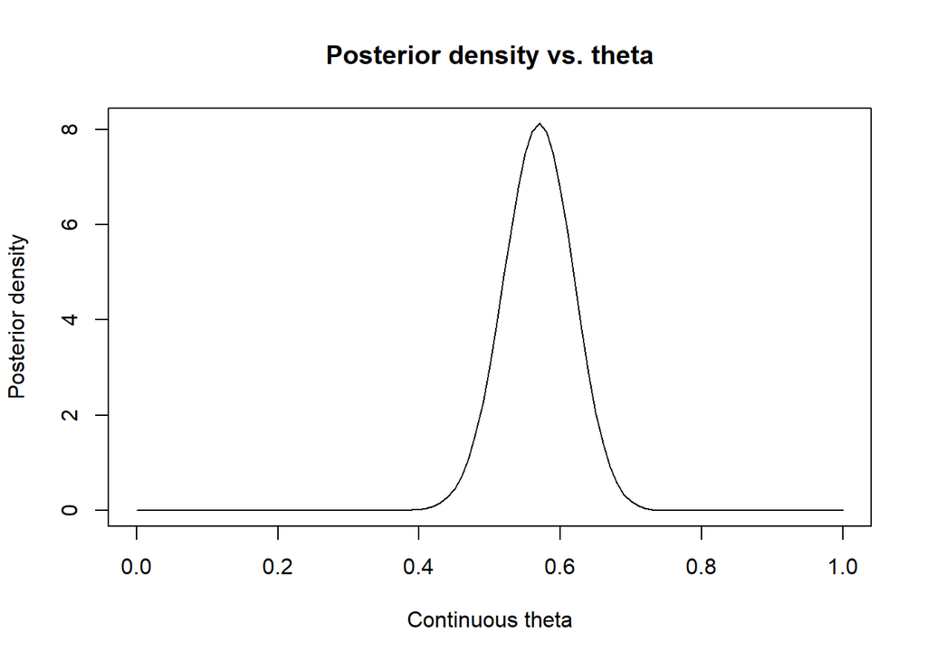

```r
posterior_beta <- dbeta(theta.any, 1+Y,1+N-Y)
plot(theta.any, type='l',posterior_beta, xlim=c(0,1), xlab = "Continuous theta", ylab = "Posterior density", main="Posterior density vs. theta")
```